# MA0501 – Tarea 4

Autores/as

Diego Alberto Vega Víquez - C38367

José Carlos Quintero Cedeño - C26152

Gabriel Valverde Guzmán - C38060

Fecha de publicación

25 de septiembre de 2025

# Ejercicio 1

**Instrucción del ejercicio 1**

Complete las demostraciones que quedaron pendientes en la clase.

**Solución**

**Teorema 1 [Weierstrass]**

Sea $f$ continua en $[a, b]$; entonces dado $\varepsilon > 0$, existe $n \in \mathbb{N}$ y $P_n(x) \in P_n$ tal que

$$\left| f(x) - P_n(x) \right| < \varepsilon, \quad \forall x \in [a, b].$$

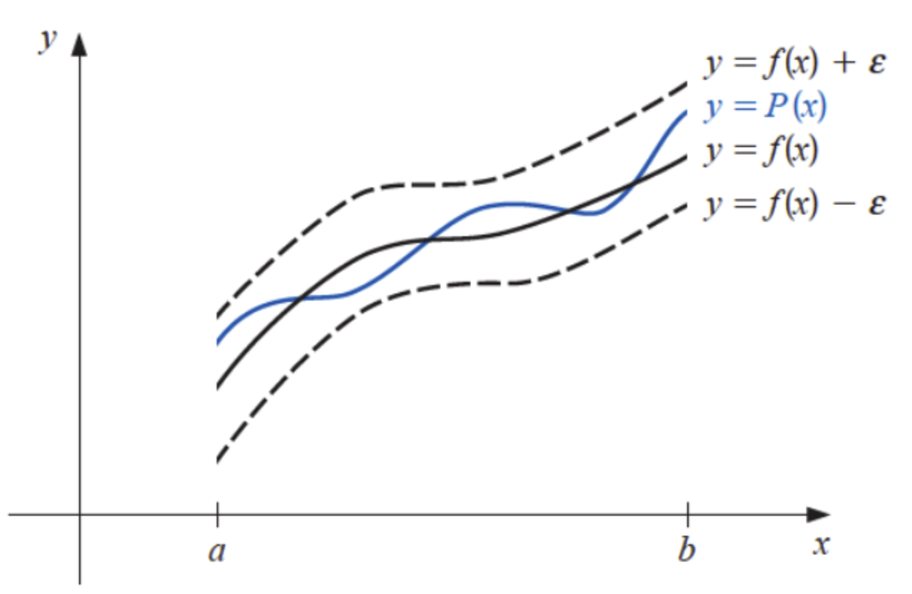

Polinomio de Bernstein

**Prueba**

Sin pérdida de generalidad, suponga que $a = 0$ y $b = 1$. Sea:

$$B_n(x) = \sum_{k=0}^n \binom{n}{k} x^k (1 - x)^{n-k} f\left( \frac{k}{n} \right),$$

se puede probar que $B_n(x) \to f(x)$ uniformemente en $[0,1]$:

Vea que

$$|B_n(x)-f(x)| \le \sum_{k=0}^n \binom{n}{k} x^k (1 - x)^{n-k} \Big|f\left( \frac{k}{n} \right) - f(x)\Big|$$
Note que se tiene una esperanza con respecto a una distribución binomial $\operatorname{Bin}(n,x)$

$$X_n\sim\operatorname{Bin}(n,x) \implies \mathbb{E}\left[f\left(\frac{X_n}{n}\right)\right] = B_n(x)$$

Entonces:

$$\lvert B_n(x) - f(x) \rvert = \left\lvert \mathbb{E}\left[f\!\left(\tfrac{X_n}{n}\right)\right] - f(x) \right\rvert$$
Dado que $f$ es continua en $[0,1]$, por el Teorema de Heine–Cantor, también es uniformemente continua.
Entonces, para todo $\varepsilon > 0$, existe $\delta > 0$ tal que:

$$|x-y| < \delta \;\;\Rightarrow\;\; |f(x) - f(y)| < \varepsilon$$
Considere dividir el dominio del índice $k$ en dos regiones:

- Cuando $\left|\tfrac{k}{n} - x\right| < \delta$
- Cuando $\left|\tfrac{k}{n} - x\right| \geq \delta$

Entonces:

$$\lvert B_n(x) - f(x) \rvert
\le
\varepsilon \cdot P\!\left(\left|\tfrac{X_n}{n} - x\right| < \delta\right)
+ 2\lVert f\rVert_\infty \cdot P\!\left(\left|\tfrac{X_n}{n} - x\right| \ge \delta\right)$$

Usando la *desigualdad de Chebyshev* aplicada a $\tfrac{X_n}{n}$, cuya varianza es $\tfrac{x(1-x)}{n}$, el segundo término tiende a $0$ uniformemente en $x\in[0,1]$.

Como el error puede hacerse arbitrariamente pequeño uniformemente en $x$, se concluye:

$$\sup_{x\in[0,1]} \lvert B_n(x) - f(x) \rvert \;\longrightarrow\; 0
\qquad \text{cuando } n \to \infty.$$

$\blacksquare$

**Teorema 3**

Sea $f \in C[a,b]$ y $f \in C^n]a,b[$, si $f$ se anula en $n+1$ puntos distintos,  
$x_0, x_1, \ldots, x_n$ en $[a,b]$. Entonces $\exists \, c \in ]a,b[$ tal que $f^{(n)}(c) = 0$.

**Prueba**

**Por inducción sobre $n$**

**Caso base: $n = 1$.**

Si $f(x_0) = f(x_1) = 0$ con $x_0 < x_1$, entonces por el Teorema de Rolle clásico, existe $c \in (x_0, x_1)$ tal que:

$$f'(c) = 0.$$

**Hipótesis de inducción:**

Supongamos que el resultado es cierto para $n = k$, es decir, si $f \in C^{k}]a,b[$ y se anula en $k+1$ puntos distintos en $[a,b]$, entonces existe $c \in (a,b)$ tal que $f^{(k)}(c) = 0$.

**Paso inductivo:**

Sea ahora $f \in C^{k+1}]a,b[$ y supongamos que $f(x_0) = f(x_1) = \dots = f(x_{k+1}) = 0$, con $x_0 < x_1 < \dots < x_{k+1}$.

Por el Teorema de Rolle, para cada par consecutivo $(x_i, x_{i+1})$, existe $c_i \in (x_i, x_{i+1})$ tal que:

$$f'(c_i) = 0.$$

Eso da una nueva colección de $k+1$ puntos $c_0 < c_1 < \dots < c_k$ donde $f'$ se anula. Entonces, por la hipótesis de inducción aplicada a $f'$, existe un punto $c \in (a,b)$ tal que:

$$f^{(k+1)}(c) = 0.$$
$\blacksquare$

**Teorema 6**

Si $P_n(x)$ es el polinomio de Lagrange que coincide con $f(x)$ en  
$x_0, x_1, \ldots, x_n$, entonces:

$$\begin{align*}
P_n(x) &= f[x_0] + f[x_0,x_1](x-x_0) + f[x_0,x_1,x_2](x-x_0)(x-x_1) \\
&\quad + \cdots + f[x_0,x_1,\ldots,x_n](x-x_0)(x-x_1)\cdots(x-x_{n-1}) \\
&= f[x_0] + \sum_{k=1}^n f[x_0,\ldots,x_k](x-x_0)\cdots(x-x_{k-1}).
\end{align*}$$

**Prueba**

Si $P_n(x)$ se escribe de la forma

$$\begin{align*}
P_n(x) &= a_0 + a_1(x-x_0) + a_2(x-x_0)(x-x_1) + \cdots \\
&\quad + a_n(x-x_0)(x-x_1)\cdots(x-x_{n-1}),
\end{align*}$$

entonces $P_n(x_0) = a_0$. Como $P_n(x_0)=f(x_0)$ se sigue que  
$a_0 = f(x_0) = f[x_0]$.

Además:

$$\begin{align*}
P_n(x_1) &= a_0 + a_1(x_1-x_0), \\
f(x_1) &= f[x_0] + a_1(x_1-x_0) \quad \Rightarrow \quad a_1 = \frac{f[x_1]-f[x_0]}{x_1-x_0} = f[x_0,x_1].
\end{align*}$$

Luego, por inducción se puede probar fácilmente que $a_k = f[x_0, x_1, \ldots, x_k]$.

**Paso base:**

Para $k = 0$, se tiene:

$$P_n(x_0) = a_0 = f(x_0),$$

por lo tanto:

$$a_0 = f[x_0].$$

**Hipótesis de inducción:**

Supongamos que para algún $k \geq 1$ se cumple que:

$$a_j = f[x_0, x_1, \dots, x_j] \quad \text{para todo } j = 0, 1, \dots, k-1.$$

**Paso inductivo:**

Queremos probar que:

$$a_k = f[x_0, x_1, \dots, x_k].$$

Evaluamos el polinomio $P_n(x)$ en $x = x_k$. Por construcción, se cumple:

$$\begin{align*}
P_n(x_k) &= a_0 + a_1(x_k - x_0) + a_2(x_k - x_0)(x_k - x_1) + \cdots \\
&\quad + a_k(x_k - x_0)(x_k - x_1)\cdots(x_k - x_{k-1}).
\end{align*}$$

Pero también sabemos que $P_n(x_k) = f(x_k)$, y por la hipótesis de inducción:

$$\begin{align*}
f(x_k) &= f[x_0] + f[x_0, x_1](x_k - x_0) + \cdots \\
&\quad + f[x_0, \dots, x_{k-1}](x_k - x_0)\cdots(x_k - x_{k-2}) \\
&\quad + a_k(x_k - x_0)\cdots(x_k - x_{k-1}).
\end{align*}$$

Entonces, restando ambos lados, obtenemos:

$$a_k = \frac{f(x_k) - P_{k-1}(x_k)}{(x_k - x_0)(x_k - x_1)\cdots(x_k - x_{k-1})},$$

pero esta fracción es exactamente la definición de la **diferencia dividida**:

$$a_k = f[x_0, x_1, \dots, x_k].$$

$\blacksquare$

**Teorema 7**

- Sea $f \in C[a,b]$.
- Sean $x_0, x_1, \ldots, x_n$, $(n+1)$ nodos distintos en $[a,b]$.

Entonces el polinomio de grado menor que coincide con $f$ y $f'$ en $x_0, x_1, \ldots, x_n$:

- Tiene grado $2n+1$.
- Está dado por

$$H_{2n+1}(x) = \sum_{j=0}^{n} f(x_j) H_{nj}(x) + \sum_{j=0}^{n} f'(x_j) \widetilde{H}_{nj}(x),$$

donde

$$H_{nj}(x) = \big[1 - 2(x - x_j)L'_{nj}(x_j)\big]L_{nj}^2(x),$$

y

$$\widetilde{H}_{nj}(x) = (x - x_j) L_{nj}^2(x).$$

- Además, el error absoluto es:

$$\left| f(x) - H_{2n+1}(x) \right| = \left| \frac{(x - x_0)^2 \cdots (x - x_n)^2}{(2n+2)!} f^{(2n+2)}(\xi) \right|, \quad \text{con } \xi \in ]a, b[.$$

**Prueba**

- Se debe demostrar que $H_{2n+1}(x_i) = f(x_i)$ para todo $i = 0, 1, \ldots, n$. Para ver esto, recordemos que:

$$L_{nj}(x_i) =
\begin{cases}
0 & \text{si } i \ne j \\
1 & \text{si } i = j
\end{cases}$$

de donde, cuando $i \ne j$:

$$H_{nj}(x_i) = 0 \quad \text{y} \quad \widetilde{H}_{nj}(x_i) = 0.$$

Mientras que:

$$H_{ni}(x_i) = [1 - 2(x_i - x_i)L'_{ni}(x_i)] \cdot 1 = 1,$$

$$\widetilde{H}_{ni}(x_i) = (x_i - x_i) \cdot 1^2$$

Luego:

$$H_{2n+1}(x_i) = \sum_{\substack{j = 0 \\ j \ne i}}^n f(x_j) \cdot 0 + f(x_i) \cdot 1 + \sum_{j=0}^n f'(x_j) \cdot 0 = f(x_i).$$

Por lo tanto:

- $H_{2n+1}(x_i) = f(x_i)$ para $i = 0, 1, 2, \ldots, n$.
- Se debe demostrar que $H'_{2n+1}(x_i) = f'(x_i)$ para todo $i = 0, 1, \ldots, n$.

Nótese que $L_{nj}(x)$ es un factor de $H'_{nj}(x)$, lo cual implica que $H'_{nj}(x_i) = 0$ cuando $i \ne j$.

Además, si $i = j$:

$$\begin{align*}
H'_{ni}(x_i) &= -2L'_{ni}(x_i)L^2_{ni}(x_i) + [1 - 2(x_i - x_i)L'_{ni}(x_i)] \cdot 2 \cdot L_{ni}(x_i)L'_{ni}(x_i) \\
&= -2L'_{ni}(x_i) + 2L'_{ni}(x_i) \\
&= 0.
\end{align*}$$

Por lo tanto, $H'_{nj}(x_i) = 0$ para todo $i = 0, 1, 2, \ldots, n$ y para todo $j = 0, 1, 2, \ldots, n$.

Además:

$$\widetilde{H}_{nj}(x_i) = L^2_{nj}(x_i) + (x_i - x_j)L'_{nj}(x_j) \cdot 2 \cdot L_{nj}(x_i)L'_{nj}(x_i),$$

de donde:

$$\widetilde{H}'_{nj}(x_i) =
\begin{cases}
0 & \text{si } i \ne j \\
1 & \text{si } i = j
\end{cases}$$

por lo tanto:

$$\widetilde{H}'_{2n+1}(x_i) = \sum_{j=0}^n f(x_j) \cdot 0 + \sum_{\substack{j = 0 \\ j \ne i}}^n f'(x_j) \cdot 0 + f'(x_i) \cdot 1 = f'(x_i).$$

es decir:

$$H'_{2n+1}(x_i) = f'(x_i) \quad \text{para } i = 0, 1, 2, \ldots, n.$$

- Sea $H(x)$ y $\widetilde{H}(x)$ dos polinomios de grado a lo sumo $2n+1$ que satisfacen:

$$H(x_i) = \widetilde{H}(x_i) = f(x_i), \quad H'(x_i) = \widetilde{H}'(x_i) = f'(x_i), \quad \text{para } i = 0, 1, \ldots, n.$$

Definamos el polinomio:

$$R(x) = H(x) - \widetilde{H}(x).$$

Entonces $R(x)$ es un polinomio de grado a lo sumo $2n+1$, y:

- $R(x_i) = H(x_i) - \widetilde{H}(x_i) = 0$,
- $R'(x_i) = H'(x_i) - \widetilde{H}'(x_i) = 0$,

para todos $i = 0, 1, \ldots, n$.

Es decir, $R(x)$ tiene **$2(n+1)$ ceros** (porque cada condición en un punto $x_i$ impone dos condiciones linealmente independientes: una en valor y otra en derivada).

Pero el grado de $R(x)$ es como máximo $2n+1$, y un polinomio no nulo de grado $d$ no puede tener más de $d$ ceros (contando multiplicidades).

Como $R(x)$ tiene más ceros que su grado, se concluye que:

$$R(x) \equiv 0,$$

es decir:

$$H(x) = \widetilde{H}(x) \quad \text{para todo } x.$$

$\blacksquare$

**Lema 1**

Si $f \in C^n[a, b]$ y $x_0, x_1, \dots, x_n$ son los $(n+1)$ nodos distintos en $[a,b]$, entonces:  
existe $\xi \in ]a, b[$ tal que:

$$f[x_0, x_1, \dots, x_n] = \frac{f^{(n)}(\xi)}{n!}.$$

**Prueba**

Consideremos el polinomio interpolador de Newton de grado $n$, que interpola a $f$ en los nodos $x_0, \dots, x_n$:

$$P_n(x) = \sum_{k=0}^n f[x_0, \dots, x_k] \prod_{j=0}^{k-1}(x - x_j).$$

Sea el **polinomio del error**:

$$R_n(x) = f(x) - P_n(x).$$

Sabemos por teoría del error de interpolación que:

$$R_n(x) = \frac{f^{(n+1)}(\xi_x)}{(n+1)!} \prod_{j=0}^n (x - x_j),$$

para algún $\xi_x$ entre el menor y el mayor de los puntos $x_j$ y $x$.

Ahora consideremos la función:

$$F(x) = f(x) - Q(x),$$

donde $Q(x)$ es el polinomio de grado $n-1$ tal que $Q(x_i) = f(x_i)$ para $i = 0, \dots, n-1$. Entonces $F(x)$ es una función que coincide con $f$ en los primeros $n$ nodos, pero no necesariamente en el último.

Aplicamos el **Teorema de Rolle generalizado** a la función:

$$g(x) = f(x) - P_n(x),$$

la cual se anula en los puntos $x_0, \dots, x_n$, ya que $P_n(x_j) = f(x_j)$. Como $f \in C^n[a,b]$, entonces $g \in C^n[a,b]$ y se anula en $n+1$ puntos.

Por el teorema, existe $\xi \in (a,b)$ tal que:

$$g^{(n)}(\xi) = 0.$$

Pero como $P_n(x)$ es de grado $n$, su derivada de orden $n$ es constante:

$$P_n^{(n)}(x) = n! \cdot f[x_0, x_1, \dots, x_n],$$

y:

$$g^{(n)}(x) = f^{(n)}(x) - P_n^{(n)}(x) = f^{(n)}(x) - n! \cdot f[x_0, \dots, x_n].$$

Entonces, si $g^{(n)}(\xi) = 0$:

$$f^{(n)}(\xi) = n! \cdot f[x_0, \dots, x_n] \quad \Rightarrow \quad f[x_0, \dots, x_n] = \frac{f^{(n)}(\xi)}{n!}.$$
$\blacksquare$

# Ejercicio 2

**Instrucción del ejercicio 2**

Implemente en R los algoritmos de interpolación polinómica vistos en clase.  
Los métodos que se deben implementar son:

1. Interpolar $f(x)$ usando el polinomio de Lagrange con el algoritmo de Neville.
2. Interpolar $f(x)$ usando el polinomio de Lagrange con el algoritmo de diferencias divididas de Newton.
3. Interpolar $f(x)$ usando el polinomio de Hermite con el algoritmo de diferencias divididas de Newton.
4. Interpolar $f(x)$ usando el “Splines” cúbicos naturales y sujetos.

Luego en general programe una función que permita graficar el polinomio de interpolación y la función correspondiente (si la hay).

**Solución** **Neville**

**Código**

```r
# Neville: interpolacion en un punto x a partir de un vector de nodos (xi) y otro de valores (f(xi))

# Retorna una lista con el valor interpolado y la matriz completa Q (la que posee todos los polinomios utilizados para la construccion del polinomio completo)

neville <- function(nodos, valores, x) {
  stopifnot(is.numeric(nodos),
            is.numeric(valores),
            length(nodos) == length(valores))
  n <- length(nodos)
  Q <- matrix(NA_real_, nrow = n, ncol = n)

  # Columna inicial con valores de Y
  Q[, 1] <-  valores

  # Construccion de la tabla de Neville
  for (i in 2:n) {
    for (j in 2:i) {
      numerador <- ((x - nodos[i - j + 1]) * Q[i, j - 1] - (x - nodos[i]) * Q[i -
                                                                                1, j - 1])
      denominador <- nodos[i] - nodos[i - j + 1]
      Q[i, j] <-  numerador / denominador
    }
  }
  return(list(valor = Q[n, n], tabla = Q))
}
```

**Lagrange por diferencias divididas de Newton**

**Código**

```r
# Lagrange.Newton: interpolacion en un punto x function# Lagrange.Newton: interpolacion en un punto x a partir de un vector de nodos y otro de valores

# Retorna una lista con el valor interpolado, la matriz para la construccion de los coeficientes, y un vector de los coeficientes del polinomio de lagrange

lagrange.newton <- function(nodos, valores, x) {
  stopifnot(is.numeric(nodos),
            is.numeric(valores),
            length(nodos) == length(valores))
  n <- length(nodos)
  Q <- matrix(NA_real_, nrow = n, ncol = n)

  Q[, 1] <- valores

  # Construccion de la tabla de diferencias de Newton
  for (i in 2:n) {
    for (j in 2:i) {
      numerador <- Q[i, j - 1] - Q[i - 1, j - 1]
      denominador <- nodos[i] - nodos[i - j + 1]
      Q[i, j] <-  numerador / denominador
    }
  }
  coeficientes <- diag(Q)

  valor = Q[1, 1]
  producto = 1

  for (i in 2:n) {
    producto <- producto * (x - nodos[i - 1])
    valor <- valor + coeficientes[i] * producto
  }
  return(list(
    valor = valor,
    tabla = Q,
    coeficientes = coeficientes
  ))
}
```

**Hermite por diferencias divididas de Newton**

**Código**

```r
# Hermite.newton: interpolacion en un punto x a partir de un vector de nodos, otro de valores y otro de derivadas

# Retorna una lista con el valor interpolado, la matriz para la construccion de los  y un vector de los coeficientes

hermite.newton <- function(nodos, valores, derivadas, x) {
  stopifnot(
    is.numeric(nodos),
    is.numeric(valores),
    is.numeric(derivadas),
    length(nodos) == length(valores),
    length(nodos) == length(derivadas)
  )
  n <- length(nodos)

  Z <- numeric(2 * n)
  Q <- matrix(0, nrow = 2 * n, ncol = 2 * n)


  # Set-up inicial de la matriz
  for (i in 1:n) {
    z0 <- 2 * i - 1
    z1 <- 2 * i
    Z[z0] <- nodos[i]
    Z[z1] <- nodos[i]
    Q[z0, 1] <- valores[i]
    Q[z1, 1] <- valores[i]
    Q[z1, 2] <- derivadas[i]
    if (i != 1) {
      Q[z0, 2] <- (Q[z0, 1] - Q[z0 - 1, 1]) / (Z[z0] - Z[z0 - 1])
    }
  }
  # Rellenar el resto de la matriz a partir de estos valores
  for (i in 3:(2 * n)) {
    for (j in 3:i) {
      Q[i, j] <- (Q[i, j - 1] - Q[i - 1, j - 1]) / (Z[i] - Z[i - j + 1])
    }
  }

  coeficientes <- diag(Q)

  valor <- Q[1, 1]
  producto <- 1

  for (i in 2:(2 * n)) {
    producto <- producto * (x - Z[i - 1])
    valor <- valor + coeficientes[i] * producto
  }
  return(list(
    valor = valor,
    tabla = Q,
    coeficientes = coeficientes
  ))
}
```

**Splines cubicos naturales**

**Código**

```r
# spline.natural: funcion que calcula la interpolacion por splines a partir de unos nodos y sus valores

# Retorna los valores de los coeficientes a, b, c, d de cada una de las n-1 ecuaciones generadas
spline.natural <- function(nodos, valores, x) {
  # Note que los valores de a corresponden a los valores de los nodos en la funcion, por lo que cuando aparezca el vector "valores" se debe entender que equivale al vector "a"
  n <- length(nodos)

  h <- numeric(n - 1)
  alfa <- numeric(n - 1)
  alfa[1] <- 0

  # Paso 1 y 2: definir los h's y alfas
  for (i in 1:(n - 1)) {
    h[i] <- nodos[i + 1] - nodos[i]
    if (i != 1) {
      alfa[i] <- (3 / h[i]) * (valores[i + 1] - valores[i]) - (3 / h[i - 1]) *
        (valores[i] - valores[i - 1])
    }
  }

  #Paso 3: definir valores iniciales de l, m, y z
  l <- numeric(n) # creo que el tamano de esto puede ser n-1
  l[1] <- 1
  m <- numeric(n - 1)
  m[1] <- 0
  z <- numeric(n) # creo que el tamano de esto puede ser n-1
  z[1] <- 0

  # Paso 4: rellenar vectores l, m, z
  for (i in 2:(n - 1)) {
    l[i] <- 2 * (nodos[i + 1] - nodos[i - 1]) - h[i - 1] * m[i - 1]
    m[i] <- h[i] / l[i]
    z[i] <- (alfa[i] - h[i - 1] * z[i - 1]) / l[i]
  }

  # Paso 5: definir valores finales
  l[n] <- 1 #creo que esto no hace falta
  z[n] <- 0 #esto tampoco
  c <- numeric(n)
  c[n] <- 0
  b <- numeric(n)
  d <- numeric(n)

  # Paso 6: sustitucion hacia atras
  for (j in (n - 1):1) {
    c[j] <- z[j] - m[j] * c[j + 1]
    b[j] <- (valores[j + 1] - valores[j]) / h[j] - (h[j] / 3) * (c[j + 1] +
                                                                   2 * c[j])
    d[j] <- (c[j + 1] - c[j]) / (3 * h[j])
  }

  # Paso extra: evaluar la interpolacion en el punto x especificado

  ## Encontramos los dos nodos que estan prensando al intervalo
  indice <- NULL
  for (i in 1:(n - 1)) {
    if (x >= nodos[i] && x < nodos[i + 1]) {
      indice <- i
    }
  }
  if(x == nodos[n]){
    indice <- n
  }
  if (is.null(indice)) {
    return("El valor de interpolacion debe estar entre dos nodos")
  }
  ## evaluamos en la funcion asociada

  valor <- valores[indice] + b[indice] * (x - nodos[indice]) + c[indice] * (x - nodos[indice])^2 + d[indice] * (x - nodos[indice])^3

  return(list(
    a = valores,
    b = b,
    c = c,
    d = d,
    valor = valor
  ))
}
```

**Splines cubicos sujetos**

**Código**

```r
# spline.sujeto: funcion que calcula la interpolacion por splines a partir de unos nodos y sus valores

# Retorna los valores de los coeficientes a, b, c, d de cada una de las n-1 ecuaciones generadas
spline.sujeto <- function(nodos, valores, derivadas, x) {
  # Note que los valores de a corresponden a los valores de los nodos en la funcion, por lo que cuando aparezca el vector "valores" se debe entender que equivale al vector "a"
  stopifnot(length(derivadas) == 2)
  n <- length(nodos)

  h <- numeric(n - 1)
  alfa <- numeric(n)

  # Paso 1 y 2: definir los h's y alfas
  for (i in 1:(n - 1)) {
    h[i] <- nodos[i + 1] - nodos[i]
    if (i != 1) {
      alfa[i] <- (3 / h[i]) * (valores[i + 1] - valores[i]) - (3 / h[i - 1]) *
        (valores[i] - valores[i - 1])
    }
  }

  alfa[1] <- 3 * ((valores[2] - valores[1]) / h[1] - derivadas[1])
  alfa[n] <- 3 * (derivadas[2] - (valores[n] - valores[n - 1]) / h[n - 1])

  #Paso 3: definir valores iniciales de l, m, y z
  l <- numeric(n) # creo que el tamano de esto puede ser n-1
  l[1] <- 2 * h[1]
  m <- numeric(n - 1)
  m[1] <- 1 / 2
  z <- numeric(n) # creo que el tamano de esto puede ser n-1
  z[1] <- alfa[1] / l[1]

  # Paso 4: rellenar vectores l, m, z
  for (i in 2:(n - 1)) {
    l[i] <- 2 * (nodos[i + 1] - nodos[i - 1]) - h[i - 1] * m[i - 1]
    m[i] <- h[i] / l[i]
    z[i] <- (alfa[i] - h[i - 1] * z[i - 1]) / l[i]
  }

  # Paso 5: definir valores finales
  l[n] <- h[n - 1] * (2 - m[n - 1])
  z[n] <- (alfa[n] - h[n - 1] * z[n - 1]) / l[n]
  c <- numeric(n)
  c[n] <- z[n]
  b <- numeric(n)
  d <- numeric(n)

  # Paso 6: sustitucion hacia atras
  for (j in (n - 1):1) {
    c[j] <- z[j] - m[j] * c[j + 1]
    b[j] <- (valores[j + 1] - valores[j]) / h[j] - (h[j] / 3) * (c[j + 1] + 2 * c[j])
    d[j] <- (c[j + 1] - c[j]) / (3 * h[j])
  }

  # Paso extra: evaluar la interpolacion en el punto x especificado

  ## Encontramos los dos nodos que estan prensando al intervalo
  indice <- NULL
  for (i in 1:(n - 1)) {
    if (x >= nodos[i] && x < nodos[i + 1]) {
      indice <- i
    }
  }
  if (x == nodos[n]) {
    indice <- n
  }
  if (is.null(indice)) {
    return("El valor de interpolacion debe estar entre dos nodos")
  }
  ## evaluamos en la funcion asociada

  valor <- valores[indice] + b[indice] * (x - nodos[indice]) + c[indice] * (x - nodos[indice])^2 + d[indice] * (x - nodos[indice])^3

  return(list(
    a = valores,
    b = b,
    c = c,
    d = d,
    valor = valor
  ))
}
```

**Funcion de graficacion**

**Código**

```r
library(tidyverse)

graficar.polinomio <- function(nodos,
                               a,
                               b,
                               metodo,
                               f = NULL,
                               valores = NULL,
                               df = NULL,
                               derivadas = NULL,
                               derivadas.clamped = NULL) {

  stopifnot(is.numeric(nodos), length(nodos) >= 2)

  # Validación: exactamente uno de f o valores
  if (is.null(f) == is.null(valores)) {
    stop("Debe proveer exactamente uno: 'f' (función) o 'valores' (numérico).")
  }

  # Valores en nodos
  if (!is.null(f)) {
    stopifnot(is.function(f))
    valores_nodos <- f(nodos)
  } else {
    stopifnot(is.numeric(valores), length(valores) == length(nodos))
    valores_nodos <- valores
  }

  # ---- Derivadas en nodos (si aplica) ----
  derivadas_nodos <- NULL

  # Si llegan ambos, priorizamos 'derivadas' y avisamos
  if (!is.null(df) && !is.null(derivadas)) {
    warning("Se pasaron 'df' y 'derivadas'; se usará 'derivadas'.")
  }

  if (!is.null(derivadas)) {
    stopifnot(is.numeric(derivadas), length(derivadas) == length(nodos))
    derivadas_nodos <- derivadas
  } else if (!is.null(df)) {
    if (is.function(df)) {
      derivadas_nodos <- df(nodos)
    } else if (is.numeric(df)) {
      stopifnot(length(df) == length(nodos))
      derivadas_nodos <- df
    } else {
      stop("`df` debe ser función o vector numérico de derivadas en los nodos.")
    }
  }

  # Wrapper vectorizado para el método (con o sin derivadas)
  if (!is.null(derivadas_nodos)) {
    H <- function(x)
      vapply(x, function(xx)
        metodo(nodos, valores_nodos, derivadas_nodos, xx)$valor, numeric(1))
  } else {
    if (is.null(derivadas.clamped)) {
      H <- function(x)
        vapply(x, function(xx)
          metodo(nodos, valores_nodos, xx)$valor, numeric(1))
    } else {
      H <- function(x)
        vapply(x, function(xx)
          spline.sujeto(nodos, valores_nodos, derivadas.clamped, xx)$valor, numeric(1))
    }
  }

  # Malla y data frames
  xi <- seq(a, b, length.out = 400)
  df_plot <- data.frame(
    x  = xi,
    Hx = H(xi),
    fx = if (!is.null(f)) f(xi) else NA_real_
  )
  df_nodos <- data.frame(x = nodos, y = valores_nodos)

  # Gráfico
  p <- ggplot(df_plot, aes(x = x))
  if (!is.null(f)) {
    p <- p +
      geom_line(aes(y = fx, color = "Original"), linewidth = 1) +
      geom_line(aes(y = Hx, color = "Interpolación"),
                linewidth = 1, linetype = "dashed") +
      scale_color_manual(values = c("Original" = "blue", "Interpolación" = "red"))
  } else {
    p <- p +
      geom_line(aes(y = Hx, color = "Interpolación"), linewidth = 1) +
      scale_color_manual(values = c("Interpolación" = "red"))
  }

  p +
    geom_point(data = df_nodos, aes(x = x, y = y),
               shape = 21, size = 3, fill = "white") +
    labs(title = paste0("Interpolación por ", deparse(substitute(metodo))),
         y = "Valor", color = "Serie") +
    theme_minimal(base_size = 14)
}
```

**Pruebas**

**Código**

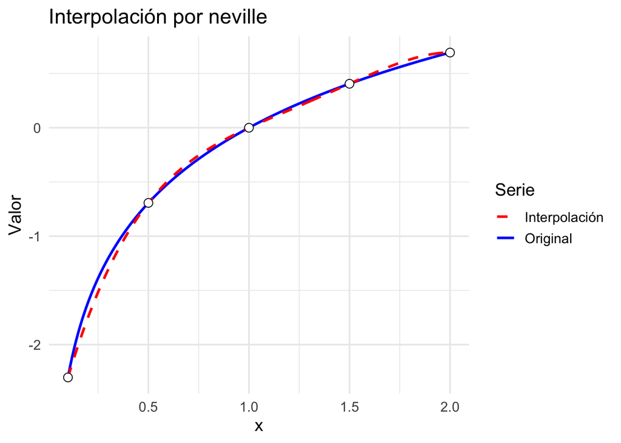

```r
f <- function(x) log(x)
df <- function(x) 1/x
nodos <- c(0.1, 0.5, 1, 1.5, 2)
graficar.polinomio(nodos, nodos[1], nodos[length(nodos)], neville, f)
```

**Código**

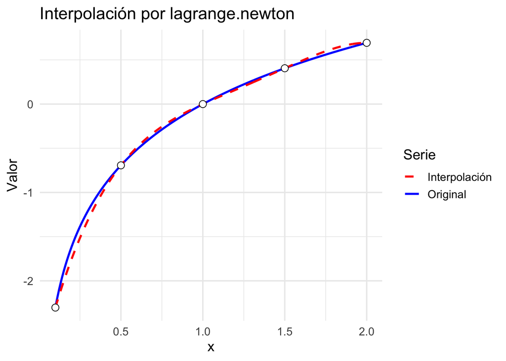

```r
graficar.polinomio(nodos, nodos[1], nodos[length(nodos)], lagrange.newton, f)
```

**Código**

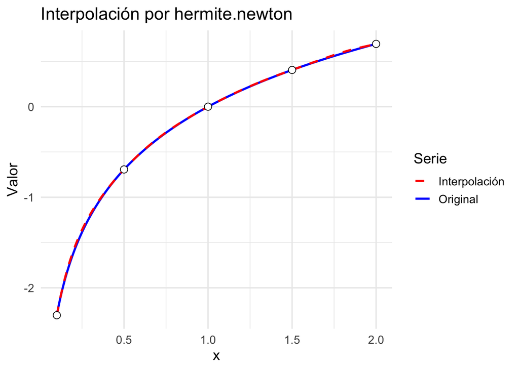

```r
graficar.polinomio(nodos, nodos[1], nodos[length(nodos)], hermite.newton, f = f, df = df)
```

**Código**

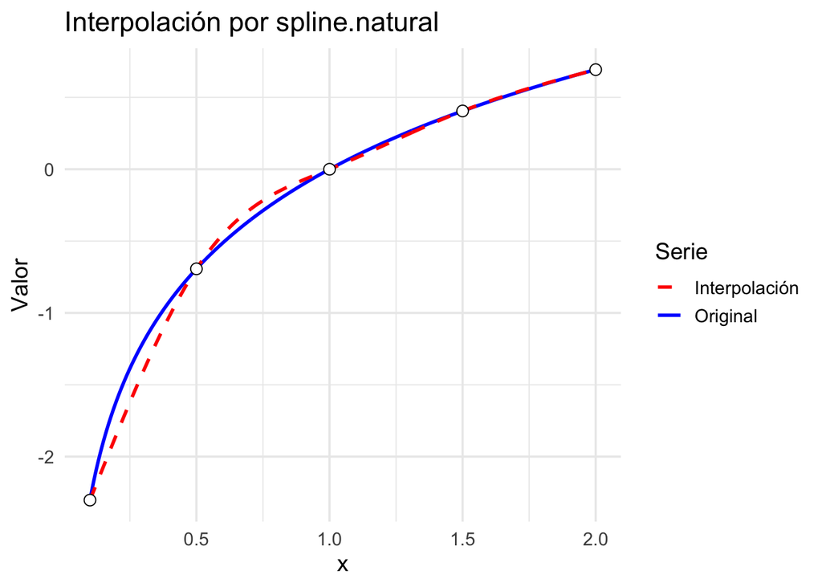

```r
graficar.polinomio(nodos, nodos[1], nodos[length(nodos)], spline.natural, f)
```

**Código**

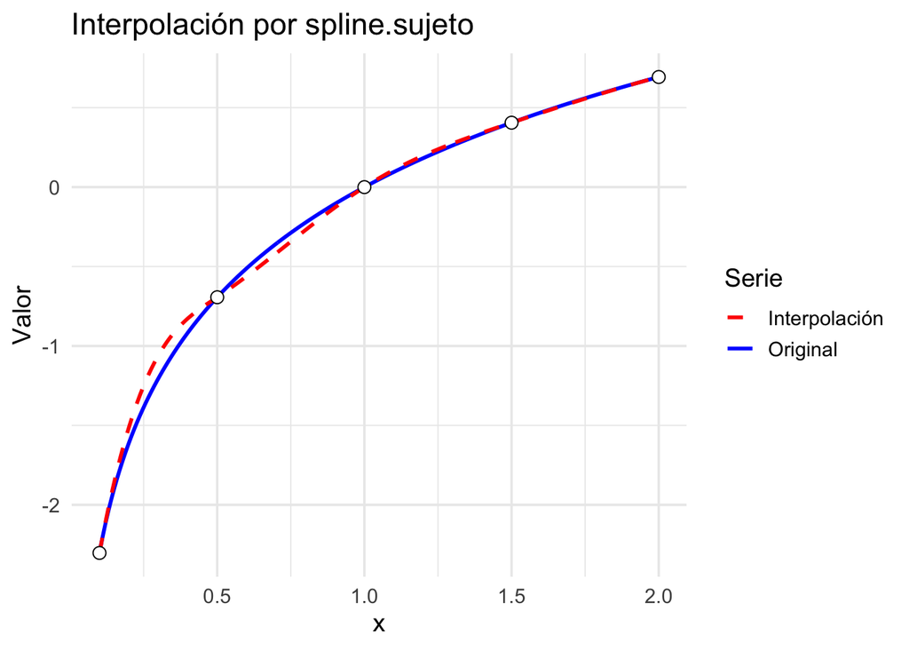

```r
graficar.polinomio(nodos, nodos[1], nodos[length(nodos)], spline.sujeto, f = f, derivadas.clamped = c(df(nodos[1]), df(nodos[length(nodos)])))
```